# Welcome to R

Session 1

Luis F. Gómez L.

luis.gomezl@unimilitar.edu.co

Distance Learning Faculty

14 September, 2026

# Please Read Me

- This presentation is based on (Chapman & Feit, 2019, Chapter 1)
- **Purpose**
  - Deliver essential knowledge within a minimal timeframe by employing hands-on learning techniques to enhance productivity in the R programming language.

# Forgetting curves

- **Learning and forgetting curves** (PBC, 2023)

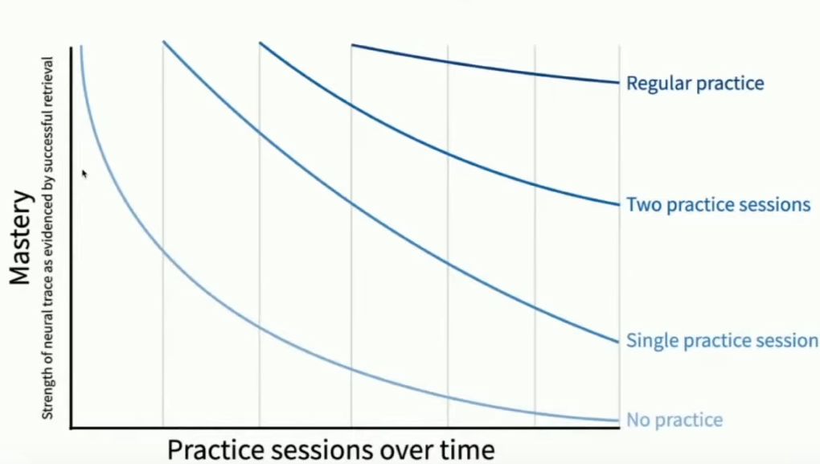

Figure 1: Learning and forgetting curves

- **Practicing and forgetting curves** (PBC, 2023)

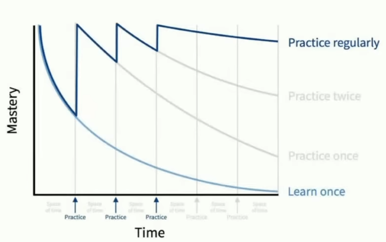

Figure 2: Practicing and forgetting curves

# Data Science

# Posit Workbench

Unites the most popular Integrated Development Environments - IDE for data science in one secure environment:

- Positron
- RStudio
- Visual Studio Code
- Jupyter (NoteBook and Lab)

# R, Positron Pro and Quarto

- **What are R and Positron Pro?** (Ismay et al., 2025, Chapter 1)

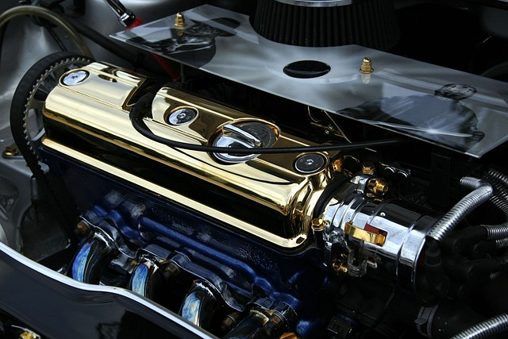

(a) R: Engine

[figure not shown]

(b) Positron Pro: Dashboard

Figure 4: Analogy of difference between R and Positron Pro

- **What is Quarto?**
  - Open-source scientific and technical publishing system
  - It is possible to integrate prose, code and results via Positron Pro (Wickham et al., 2023, Chapter 29)

[figure not shown]

Figure 5: Quarto workflow

- **Using R and Quarto via Positron Pro** (Ismay & Kim, 2020, Chapter 1)
  - Don’t worry about Quarto because it will be embedded in Positron Pro

[figure not shown]

(b) Positron Pro

Figure 6: R versus Positron Pro

[figure not shown]

Figure 7: Positron Layout

# R packages

- **What are R packages?** (Ismay et al., 2025, Chapter 1)

[figure not shown]

(a) R: A new phone

[figure not shown]

(b) R packages: Apps you can download

Figure 8: Analogy of R vs R packages

```r
packages <- c("tidyverse")

for (package in packages) {
  if (!(package %in% rownames(installed.packages()))) {
    install.packages(package)
  }
}
```

```r
library(tidyverse)
```

- **Installing the tidyverse as an example**
  - Copy and paste this code in the console. The `tidyverse` package is already installed in your session so nothing will happen
  - If you don’t have installed the `tidyverse` then the package is going to be installed
- **Loading a package**
  - Loading a package is like opening an app you already installed on your phone where you need to do it every time you want to use the app

# Please help me: Errors, warnings, and messages

```r
x <- c(1, 2, 3, 4, 5)
X
```

```
Error:
! object 'X' not found
```

```r
sqrt(-9)
```

```
Warning in sqrt(-9): NaNs produced
```

```
[1] NaN
```

- **Error**: Generally when there’s an error, the code will not run and a message will try to explain what went wrong (Ismay et al., 2025, Chapter 1)
- **Warning**: Generally your code will still work, but with some caveats (Ismay et al., 2025, Chapter 1)

```r
library(tidyverse)
```

[output not shown]

- **Message**: it’s just a friendly message (Ismay et al., 2025, Chapter 1)
  - Read it, wave back at R, and thank it for talking to you (Ismay et al., 2025, Chapter 1)

# R for Marketing Research and Analytics, 2nd Ed

- **Download from UMNG Springer Link database**:
  - https://doi-org.ezproxy.umng.edu.co/10.1007/978-3-030-14316-9
- **Check the book site**:
  - http://r-marketing.r-forge.r-project.org

# Acknowledgments

- To my family that supports me
- To the taxpayers of Colombia and the [**UMNG students**](https://www.umng.edu.co/estudiante) who pay my salary
- To the [**Business Science**](https://www.business-science.io/) and [**R4DS Online Learning**](https://www.rfordatasci.com/) communities where I learn [**R**](https://www.r-project.org/about.html) and [**$\pi$-thon**](https://www.python.org/about/)
- To the [**R Core Team**](https://www.r-project.org/contributors.html), the creators of [**Positron**](https://positron.posit.co/), [**Quarto**](https://quarto.org/) and the authors and maintainers of the packages [**tidyverse**](https://CRAN.R-project.org/package=tidyverse) and [**tinytex**](https://CRAN.R-project.org/package=tinytex) for allowing me to access these tools without paying for a license

# References

Chapman, C., & Feit, E. M. (2019). *R For Marketing Research and Analytics* (2nd ed. 2019). Springer International Publishing : Imprint: Springer. https://doi-org.ezproxy.umng.edu.co/10.1007/978-3-030-14316-9

Conway, D. (2013). *The Data Science Venn Diagram*. http://drewconway.com/zia/2013/3/26/the-data-science-venn-diagram

Ismay, C., & Kim, A. Y.-S. (2020). *Statistical inference via data science: A ModernDive into R and the tidyverse*. CRC Press, Taylor & Francis Group. https://moderndive.com/index.html

Ismay, C., Kim, A. Y., & Valdivia, A. (2025). *Statistical Inference via Data Science: A ModernDive into R and the Tidyverse* (2nd ed.). Chapman; Hall/CRC. https://moderndive.com/v2/

PBC, P. (2023). *Learning Python for Data Science with Posit Academy - YouTube*. https://www.youtube.com/live/IpUhSZPqTaE?feature=share&t=401

Wickham, H., Çetinkaya-Rundel, M., & Grolemund, G. (2023). *R for data science: Import, tidy, transform, visualize, and model data* (Second edition). O’Reilly. https://r4ds.hadley.nz/